# Homework 6

**Exercise 1 (Multiplying on the right)** Let $P$ be an *irreducible* transition matrix on a finite state space $S$ of size $n$. Let $h :S \to \mathbb{R}$ be a function on $S$, and regard $h$ as a column vector. Call a function $h$ **harmonic** if $Ph = h$.

- Show that every harmonic function is a constant. Hint: every function achieves its maximum, since $S$ is finite. Let $M= \max_{s \in S} h(s) = h(s)$ for some $s \in S$. First, show that $h(z) = M$ for every $z \in S$ for which $p_{sz} >0$. Finally, use irreducibility, to extend the claim for all $z \in S$.
- Show that the matrix $P- I$ has a kernel of dimension $1$; that is, the set of vectors $v$ such that $(P-I)v = 0 \in \mathbb{R}^n$ has dimension $1$.
- Recall that the rank of a matrix is equal to the rank of its transpose. Use this fact to show that the set of vectors $v$ such that $v = vP$ has dimension $1$.
- Use the previous part to argue that there is at most one stationary distribution for $P$.

*Solution.*

- As suggested, let $h$ be a harmonic function obtaining its maximum value at $h(s) = M$. Suppose $p_{sz} >0$. Since $Ph = h$, we have

$$\begin{eqnarray*}
M =& &h(s) \\
&=& (Ph)_s \\
&=& \sum_j p_{sj} h(j) \\
&=& p_{sz}h(z) + \sum_{j\not=z} p_{sj} h(j) \\
&\leq& p_{sz}h(z) + (1-p_{sz})M.
\end{eqnarray*}$$
Rearranging, we obtain
$$p_{sz}M \leq p_{sz}h(z),$$
so that $h(z) \geq M$ and since $M$ is the maximum, we have the desired equality.

Since $P$ is irreducible, for every $z \in S$, there is an $n \geq 1$ such that $p_{sz}(n) >0$. Since we also have
$$P^n h = h,$$
the previous argument with $P^n$ taking the place of $P$ applies to show that $h(z) = M$.

- Notice any solution to $(P-I)v = 0$ must be harmonic and thus must be a constant function/vector, so that the nullspace of $P-I$ is generated by the constant (column) vector $(1,1,1)$.
- By the rank-nullity theorem, the matrix $P_I$ has rank $n-1$, and thus its transpose, $P^t -I$ also has a kernel of dimension $1$. Notice that $v = vP$ if and only $P^tv^t = v^t$; that is, $v$ is a solution to $vP = v$ if and only if $v^t$ is the nullspace of $P^t - I$. Hence the set subspace of solutions to $v P = v$ has dimension $1$.
- By definiton, a stationary distribution $\pi$ satisfies $\pi = \pi P$ and $\pi$ has all nonnegative entries that sum to $1$; thus if $\pi'$ is another stationary distribution, since the solution space has dimension $1$, we must that $c \pi = \pi'$–summing both sides yields that $c=1$.

**Exercise 2** Consider the Markov chain $X$ on five states $\{1,2,3,4,5\}$ started at $1$ with transition matrix given by

```r
P <- matrix(c(1/4, 1/4, 1/2, 0,0,
              1/4, 1/8,1/8,0,1/2,
              1/4,0,0, 1/2, 1/4,
              0,0,0,1/2, 1/2, 1/3, 1/3, 0, 0, 1/3), nrow =5)
P <-t(P)
P
```

```
##           [,1]      [,2]  [,3] [,4]      [,5]
## [1,] 0.2500000 0.2500000 0.500  0.0 0.0000000
## [2,] 0.2500000 0.1250000 0.125  0.0 0.5000000
## [3,] 0.2500000 0.0000000 0.000  0.5 0.2500000
## [4,] 0.0000000 0.0000000 0.000  0.5 0.5000000
## [5,] 0.3333333 0.3333333 0.000  0.0 0.3333333
```

For each $s \in \{1,2,3,4,5\}$, let $T^s = \inf \{ n \geq 1: X(n)=s | X(0)=s\}$.

- By running simulations, estimate $\mathbb{E} T^s$, for each $s$.
- Using our theory of Markov chains, compute *exactly* $\mathbb{E} T^s$, for each $s$.

*Solution.* It is easy to verify that $P$ is irreducible and aperiodic, since $P^3$ has all positive entries:

```r
Q = P  %*% P%*%P
Q
```

```
##           [,1]      [,2]       [,3]      [,4]      [,5]
## [1,] 0.2083333 0.1575521 0.13671875 0.2031250 0.2942708
## [2,] 0.2560764 0.1903212 0.17643229 0.1015625 0.2756076
## [3,] 0.2152778 0.1657986 0.09114583 0.1875000 0.3402778
## [4,] 0.2222222 0.2013889 0.10416667 0.1250000 0.3472222
## [5,] 0.2731481 0.1915509 0.16840278 0.1041667 0.2627315
```

Thus we know that the stationary distribution $\pi$ satisfies

$$\pi_s = (\mathbb{E} T^s)^{-1}.$$

We easily compute $\pi$.

```r
eigen(t(P))
```

```
## eigen() decomposition
## $values
## [1]  1.0000000+0.0000000i  0.3362035+0.2981548i  0.3362035-0.2981548i
## [4] -0.2320368+0.0647526i -0.2320368-0.0647526i
##
## $vectors
##               [,1]                  [,2]                  [,3]
## [1,] -0.5124053+0i -0.2980155+0.1574620i -0.2980155-0.1574620i
## [2,] -0.3877662+0i -0.2746034-0.1061630i -0.2746034+0.1061630i
## [3,] -0.3046734+0i -0.2085874+0.3796865i -0.2085874-0.3796865i
## [4,] -0.3046734+0i  0.6367273+0.0000000i  0.6367273+0.0000000i
## [5,] -0.6335822+0i  0.1444790-0.4309855i  0.1444790+0.4309855i
##                       [,4]                  [,5]
## [1,] -0.3520380-0.0196264i -0.3520380+0.0196264i
## [2,]  0.3405425+0.3764344i  0.3405425-0.3764344i
## [3,]  0.5751293+0.0000000i  0.5751293+0.0000000i
## [4,] -0.3897784-0.0344780i -0.3897784+0.0344780i
## [5,] -0.1738554-0.3223300i -0.1738554+0.3223300i
```

```r
stat = eigen(t(P))$vectors[,1]
stat = stat/sum(stat)
stat
```

```
## [1] 0.2390953+0i 0.1809370+0i 0.1421648+0i 0.1421648+0i 0.2956381+0i
```

**Exercise 3** By running simulations, verify the central limit theorem for renewal processes, in the case where the inter-arrival times are given by a gamma distribution with shape $n=2$ and rate $\lambda=3$.

*Solution.* The gamma distibution is available in R via; rgamma(n, shape, rate = 1, scale = 1/rate). For this question, we can also see it as the sum of two independent exponentials of rate $\lambda = 3$. The following code is adapted from the excessive life code; it gives the number of arrivals by time $t$:

```r
number<- function(t){
  arr  = rexp(1,3) + rexp(1,3)
  inter = arr
  while(arr[length(arr)] <t){
    inter <- c(inter, (rexp(1,3) + rexp(1,3))  )
    arr <- c(arr, arr[length(arr)] + inter[length(inter)])
}
length(arr)
}
```

Now we code the normalized quantity in the central limit theorem

```r
nz <- function(t){
vary = 2*(1/9)
    mu = 2*(1/3)
ratio=  ( number(t) - (t/mu)  )/ (   ( (t* vary)/ mu^3)^(0.5)   )
  ratio
}
```

We call $nz(300)$ for a large number of times and plot a histogram and compare with the density of the standard normal.

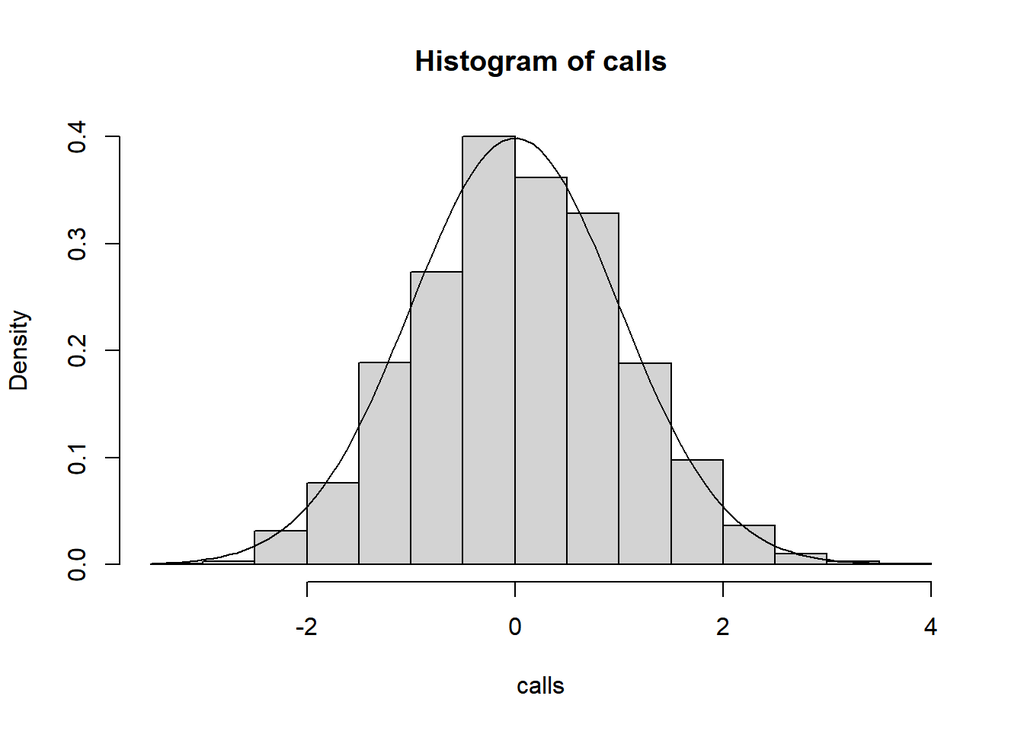

```r
calls = replicate(5000, nz(300))
hist(calls, prob=TRUE)
curve(dnorm(x), add=TRUE)
```

**Exercise 4** Check (by pen and paper), the law of large numbers and the central limit theorem for renewal processes, for the special case where the renewal process is a Poisson process.

*Solution.* Let $N$ be a Poisson counting process with intensity $\lambda$; then the inter-arrival times are exponential with rate $\lambda = \mu^{-1}$, which have variance $\mu^2$ We know that $N(t)$ is a random variable with Poisson mean $\lambda t$. We already have a proof that $N(t)/t \to \lambda$, but now we can also verify that, without a limit, we have
$$\mathbb{E} N(t) /t = \lambda.$$

In addition, the sum of independent Poissons is again Poisson, thus $N(n)$ has the same law as the sum of $n$ independent Poisson random variables $X_i$ with mean $\lambda$, and variance $\lambda$. Considering, first only integer times, $n$, we have that

$$\frac{N(n) -n\lambda}{\sqrt{n \lambda}}$$

has the same law as
$$\frac{ \sum_{i=1} ^n X_i - n \lambda}{\sqrt{n \lambda}},$$
which the regular central limit assures us converges in distirbution to a standard normal.

Let $[t]$ denote the integer part of $t$, so that $[1.5] = 1$. Notice that

$$N([t] -1) \leq N(t) \leq N( [t] +1)$$
so that standard arguments give the result for general $t$.

**Exercise 5** Prove that if $s$ is a recurrent state of a Markov chain that is started at $s$, then with probability one, it must return to that state for infinitely many $n \in \mathbb{Z}^{+}$

*Solution.* Let $T_i$ be the $i$th return time to $s$, so that $T_0 = 0$. We already know that $T_1 < \infty$ with probability one. By the Strong Markov property, the same holds for all the $T_i$; in particular,

$$\mathbb{P}(T_1 < \infty, T_2 < \infty) = (\mathbb{P}(T_1 < \infty))^2.$$
Hence

$$\mathbb{P} \big( \bigcap _{i=0} ^{\infty} \{ T_i < \infty \} \big) = 1.$$

**Exercise 6** Prove that if an irreducible Markov chain has a recurrent state, then all the states must also be recurrent.

*Solution.* Let $s\in S$ be the given recurrent state of the Markov chain $X$, so that we know that

$$T^s = \inf \{ n \geq 1: X_n=s | X_0 = s\}$$

is finite with probability one. Let $t \in S$ be another state. By irreducibility, there exists $n \geq 1$, so that $p_{st}(n) >0$ and in $n$ steps it is possible to reach $t$ from $s$, and on this event, we still must have with the chain will return to $s$. Thus by the strong Markov property, $T^{ts}$, the time it takes for a chain starting at $t$ to reach $s$ is finite with probability one.

*One* way to return to $t$ starting at $t$, is to go to $s$ and then from $s$ to go to $t$. Thus it suffices to argue that $T^{st}$ is also finite with probability one. Since each time the chain returns to $s$, we have an independent nonzero chance of reaching $t$ again, by the strong Markov property, this will eventually happen with probability $1$.

- Version: 23 November 2020
- [Rmd Source](https://tsoo-math.github.io/ucl/QHW6-sols.Rmd)